# Understanding and addressing missing data in NYTD

August 22, 2018

## Summer of NYTD Session 3

*Session starts at 12pm EST*

- Please turn your video off and mute your line
- This session is being recorded
- See ZOOM Help Center for connection issues: https://support.zoom.us/hc/en-us
  - If issues persist and solutions cannot be found through Zoom contact hl332@cornell.edu

## Introduction

- Summer schedule:
  - August 8th - Introduction
  - August 15th - Data Structure
  - **August 22nd - Expert Presentation I**
  - August 29th - Expert Presentation II
  - September 5th - Linking to NCANDS & AFCARS
  - September 12th - Research Presentation I
  - September 19th - Research Presentation II

## Today's Presentation: Understanding and addressing missing data in NYTD

Presenters: Michael Dineen (med39@cornell.edu) and Frank Edwards (fedwards@cornell.edu)

## Agenda for today's webinar

- Develop a clear understanding of the design of the NYTD and the structure of the sample
- Discuss differences in the composition of state samples and methods states use to collect data
- Discuss sources of missing data and non-response
- Discuss the theories behind statistical approaches to missing data, with a focus on multiple imputation
- Discuss some practical strategies to address missing data in the NYTD

## NYTD Design

## Understanding the structure of the National Youth in Transition Database (NYTD)

- The user's guide and codebook are your friends
- The NYTD Outcomes Survey is ongoing, with new cohorts commencing every 3 years, starting with Federal Fiscal Year 2011.
  - Cohort 1 was 17 in 2011, Cohort 2 was 17 in 2014
- Each Cohort has three waves, with two years between surveys
  - Cohort 1 [2011, 2013, 2015], Cohort 2 [2014, 2016, 2018]

## Who is in the NYTD?

- Any youth who is in foster care within the 45-day period following their 17th birthday is eligible for the survey.
- The baseline survey is not a sample - the entire population of youth who meet the inclusion criteria is surveyed.
- Demographic data on all youth in the baseline population is included in the baseline (Wave 1) data.

## Who is in the cohort?

- Youth who:
  - Are in foster care at the time they took the survey
  - Answer at least one survey question on the baseline survey
  - Took the survey within 45 days of their 17th birthday
- Follow-up surveys are conducted during the six-month AFCARS reporting period that includes the youth's 19th and 21st birthdays.

## State sampling

- States are permitted to sample the cohort for the age 19 and 21 follow-ups.
- Simple random sampling is required
- Sampling is done once, after the cohort is determined.
- The same sample is used for both the age 19 and age 21 surveys.

## Sources of missing data in the NYTD

## Sources of missing data: not-in-cohort

- Response in Wave 1 to voluntary questions is required to be selected for the cohort
  - Youth who do not respond to the baseline survey are not followed-up at subsequent waves, so all survey data for these cases are missing
- However, demographic data are present
- This means that the cohort is not a random or representative sample if choosing to respond is associated with any of the variables in the study.

## Wave non-response

- Youth did not participate in a wave.
- All survey data for that wave will be missing for that row.
- Demographics will be present.

## Reasons for non-response

- Youth declined: The State agency located the youth successfully and invited the youth's participation, but the youth declined to participate in the data collection.
- Parent declined: The State agency invited the youth's participation, but the youth's parent/guardian declined to grant permission.
  - This response may be used only when the youth has not reached the age of majority in the State and State law or policy requires a parent/guardian's permission for the youth to participate in information collection activities.

## Reasons for non-response

- Incapacitated: The youth has a permanent or temporary mental or physical condition that prevents him or her from participating in the outcomes data collection.
- Incarcerated: The youth is unable to participate in the outcomes data collection because of his or her incarceration.
- Runaway/missing: A youth in foster care is known to have run away or be missing from his or her foster care placement.
- Unable to locate/invite: The State agency could not locate a youth who is not in foster care or otherwise invite such a youth's participation.
- Death: The youth died prior to his participation in the outcomes data collection.

## Question non-response

- This is the easiest form of missing data to deal with, but rare in NYTD

## Approaches to missing data 101

## Why should we care?

- Most statistical software will conduct "complete-case analysis" by default
  - This uses only those observations where regression outcomes and all predictors are non-missing
- Depending on how much data is missing in the variables you've chosen, this may result in throwing away a lot of perfectly good information!
- This (at minimum) biases your standard errors, and may bias your parameter point estimates
- With a few assumptions, we can correct the problem

## Why are data missing?

- **Missing completely at random (MCAR)**: The probability of a value being missing is the same for all observations in the data. Missingness is determined by a coin flip/dice roll
- **Missing at random (MAR)**: The probability of a value being missing is *not* completely at random, depends only on available (observed) information. The probability of a value being missing is determined by other variables in the data
- **Non-random missing data (MNAR)**: The probability of a value being missing depends on either *A)* some unobserved variable or *B)* the value itself (censorship)

## Basic approaches to missing data

- Listwise deletion (complete case analysis)
  - Appropriate for data with very few missing observations, or when missingness is completely at random and missingness is rare (independent of all observed and unobservable variables)
- Using alternative information (e.g. borrowing observation of sex from prior survey wave)
- Nonresponse weighting
  - Becomes difficult when many variables are missing, sub-populations of interest differ

## Basic approaches to missing data

- Deterministic imputation methods
  - Many examples: linear interpolation or last observed, regression imputation
  - This is generally a bad idea. Covariance estimates and standard errors are biased downward

## Basic approaches to missing data

- Multiple imputation
  - Iterative modeling of all missing outcomes/predictors in model
  - Produces fake datasets, allows you to average over uncertainty generated by missing data
  - Does not recover "true" values
  - Under missing at random assumption, generates unbiased parameter and variance estimates

## What muliple imputation does:

- Has two effects on model uncertainty
  - Increases your N because we aren't deleting data (pushes standard errors downward)
  - Adds in appropriate noise due to uncertainty around where missing values are (pushes standard errors upward)
- If missingess is associated with observables, MI can correct bias in parameter estimates

## My preferred approach

- Understand your data!
  - Read the documentation
  - Do plenty of exploratory data analysis (cross tabs, data visuals, descriptives, look at the raw data)
  - Develop an understanding of the mechanisms of missing data in each dataset you use
  - Test your ideas for mechanisms of missing data when feasible

## My preferred approach

- Use available information
  - Borrow data from other observations when possible
  - Some variables are time-stable (age) and can be borrowed from prior observations - but remember cautions against deterministic imputation and inducing bias

## My preferred approach

- If MAR is a reasonable assumption (it often is), conduct multiple imputation
  - Because MAR is conditional on observables, including many variables in imputation models is often a good idea
- Apply preferred final model / analysis over each imputed dataset, combine with Rubin's rules, report revised estimates.

## Applying missing data methods to NYTD: a very brief introduction

## Some notes before starting

- This is a very brief introduction, more work will be required to get it right for your analysis
- I'm using R (and the mice package) for my demo, but all major statistical packages (Stata, SAS, SPSS) should be able to use similar techniques
- All code (and slides, but no data!) is available at https://github.com/f-edwards/nytd_missing_data_demo
- We are using NYTD Outcomes File, Cohort Age 17 in FY2011, Waves 1-3 (NDACAN Dataset 202).
- Submit data requests at https://www.ndacan.cornell.edu/datasets/request-dataset.cfm

## Load in packages and data

```r
### load required packages
library(tidyverse)
library(lubridate)
library(mice)
### read in tab separated data
nytd<-read_tsv("Outcomes_C11W3v2.tab")
```

## Create cohort subset

```r
### count total population, cohort based on baseline
pop<-sum(nytd$Wave==1)
### subset on those in cohort
cohort<-nytd%>%
  filter(FY11Cohort==1)%>%
  filter(!(SampleState==1 & InSample==0))
```

## Describe response rates

```r
## response rate by wave
nytd%>%filter(FY11Cohort==1)%>%
  filter(Responded==1)%>%
  group_by(Wave)%>%
  summarise(baseline = pop, responses = n(), response_rate = n()/pop)
```

```
## # A tibble: 3 x 4
##    Wave baseline responses response_rate
##   <int>    <int>     <int>         <dbl>
## 1     1    29104     15597         0.536
## 2     2    29104      7897         0.271
## 3     3    29104      7470         0.257
```

## Response rates for cohort

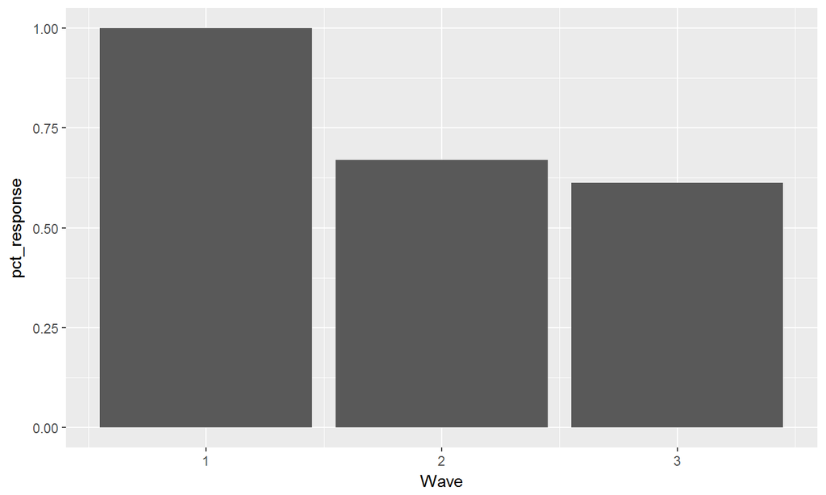

## Question non-response

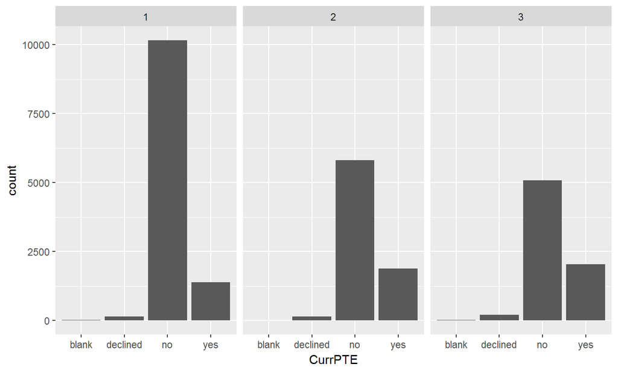

## What drives non-response?

## Non-response by gender

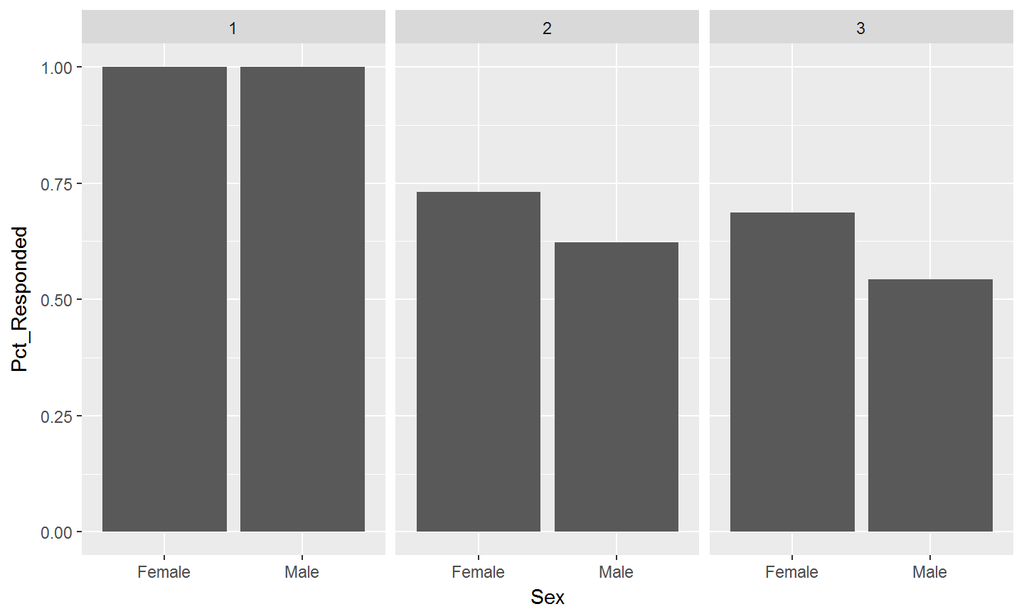

## Non-response by race and wave (white / non-white)

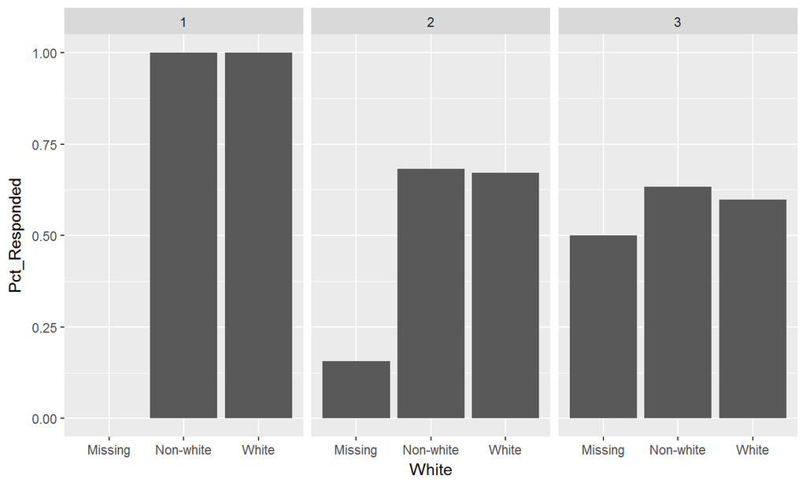

## Proceeding with MI

- For the purposes of demonstration, we'll assume that CurrPTE is MAR conditional on sex, race/ethnicity, and age (Wave).
- But a full imputation model should include *AS MANY* predictors as possible to maximize predictive performance and satisfy MAR assumption. This is just a demonstration of what we can do
- Note that models grow in complexity as new predictors (with their own missing values) increase computation time

## Set up imputation dataset

```r
to_impute<-cohort%>%
  select(Wave, Sex, CurrPTE, RaceEthn)%>%
  mutate(CurrPTE = ifelse(CurrPTE == 77, NA, CurrPTE))%>%
  mutate(Sex = factor(Sex),
         Wave = factor(Wave),
         CurrPTE = factor(CurrPTE),
         RaceEthn = factor(ifelse(RaceEthn==99, NA, RaceEthn)))

head(to_impute)
```

```
## # A tibble: 6 x 4
##   Wave  Sex    CurrPTE RaceEthn
##   <fct> <fct>  <fct>   <fct>
## 1 1     Female 0       1
## 2 1     Female 0       3
## 3 1     Female 1       1
## 4 1     Male   0       1
## 5 1     Female 0       3
## 6 1     Male   2       7
```

## Look at missing data patterns

```r
### install.packages("mice") if needed
### wonderful tutorials at https://stefvanbuuren.github.io/mice/
summary(to_impute)
```

```
##  Wave          Sex        CurrPTE         RaceEthn
##  1:11713   Female:17109   0   :21066   1      :15872
##  2:11712   Male  :18235   1   : 5307   2      :10431
##  3:11994   NA's  :   75   2   :  529   7      : 6173
##                           NA's: 8517   6      : 1499
##                                        3      :  605
##                                        (Other):  377
##                                        NA's   :  462
```

## Predictors and methods

```r
imp<-mice(to_impute, maxit=0, seed = 123)
### show the predictor matrix
imp$predictorMatrix
```

```
##          Wave Sex CurrPTE RaceEthn
## Wave        0   0       0        0
## Sex         1   0       1        1
## CurrPTE     1   1       0        1
## RaceEthn    1   1       1        0
```

```r
### show imputation methods, logistic and multinomial
imp$method
```

```
##      Wave       Sex   CurrPTE  RaceEthn
##        ""  "logreg" "polyreg" "polyreg"
```

## Impute data with 5 imputed data sets

```r
imp_out<-mice(to_impute,
              maxit = 10,
              m = 5,
              seed = 123,
              predictorMatrix = imp$predictorMatrix,
              method = imp$method)
```

## Check out convergence

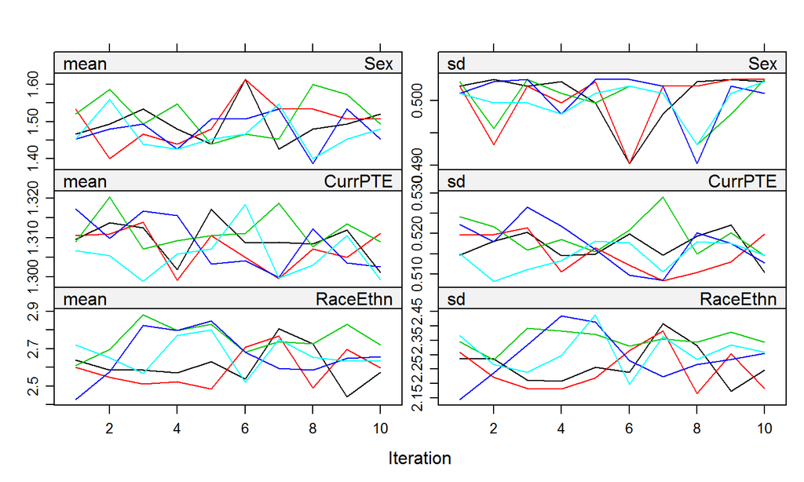

## Check out effects of imputation on CurrPTE

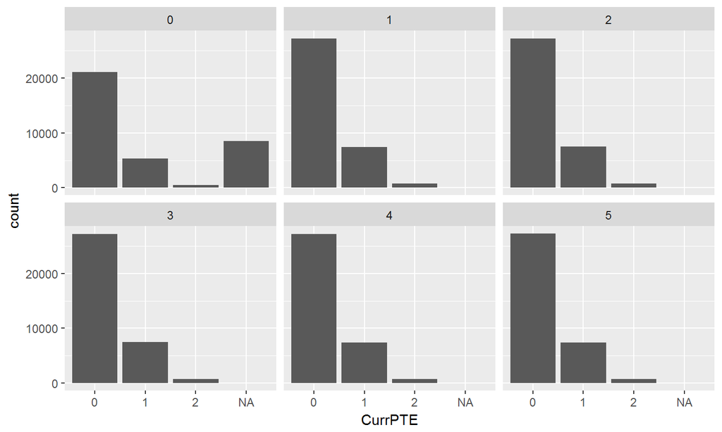

## Compare imputed to original data

```
## # A tibble: 6 x 3
##   .imp  pct_PTE pct_nonPTE
##   <fct>   <dbl>      <dbl>
## 1 0       0.150      0.595
## 2 1       0.210      0.769
## 3 2       0.211      0.767
## 4 3       0.212      0.767
## 5 4       0.210      0.769
## 6 5       0.209      0.770
```

## Only among non-missings

```
## # A tibble: 6 x 3
##   .imp  pct_PTE pct_nonPTE
##   <fct>   <dbl>      <dbl>
## 1 0       0.197      0.783
## 2 1       0.210      0.769
## 3 2       0.211      0.767
## 4 3       0.212      0.767
## 5 4       0.210      0.769
## 6 5       0.209      0.770
```

## Conduct a pooled analysis

```r
### fit logistic regression on each imputed data set
fit_imp<-with(imp_out, glm(CurrPTE == "1" ~ (Sex=="Male") +
                             Wave + RaceEthn,
                       family = "binomial"))
## Pool results with Rubin's rules
pooled<-pool(fit_imp)
### just with observed data
fit<-with(to_impute, glm(CurrPTE == "1" ~ (Sex=="Male") +
                           Wave + RaceEthn,
                       family = "binomial"))
```

## Compare models

```r
library(broom)
# with only observed
tidy(fit)[1:2, 1:3]
```

```
##                term   estimate  std.error
## 1       (Intercept) -1.8688112 0.03678118
## 2 Sex == "Male"TRUE -0.1768677 0.03153402
```

```r
# with imputed data
summary(pooled)[1:2, 1:2]
```

```
##                          est         se
## (Intercept)       -1.8656265 0.03539415
## Sex == "Male"TRUE -0.1830675 0.02716801
```

## Going deeper

## What we accomplished

- We adjusted our models for non-response bias between waves
  - We imputed 5 complete datasets for the cohort, averaged over uncertainty in our models
- This appears to matter for our estimates of Employment ~ Gender

## This approach is incomplete

- We haven't dealt with selection into the cohort
- We haven't fully explored the mechanisms of missing data
- Our model is too simplistic
  - Incorporate documented reason for non-response into models
  - Extend to focal variables for your analysis
  - Think carefully about why your variable is missing, what other observed variables in the data may help you estimate uncertainty
- Bonus points: go multilevel

## Possible extensions of this method

- Theoretically, the method could be used to estimate uncertainty intervals for parameters for the full NYTD-eligible population
  - Though this would be computationally intensive and
  - Stretch the MAR assumption perhaps too far (if participation in the cohort is conditional on unobservables)

## Final notes

- Approaches to missing data are not one-size fits all.
- Think hard about why your data are missing
- If they are MAR conditional on observables, MI may be appropriate

## Further reading

- Rubin, "Multiple Imputation for Nonresponse in Surveys"
- Gelman and Hill, "Data Analysis Using Regression and Multilevel/Hierarchical Models"
- van Buuren, "mice: Multivariate Imputation by Chained Equations in R"

## Questions?

Please use the chat feature in Zoom to submit questions during the Q and A

Code and slides available at:

https://github.com/f-edwards/nytd_missing_data_demo

Frank: fedwards@cornell.edu Michael: med39@cornell.edu

## Next Week

- Date: Wednesday August 29th from 12pm-1pm
- Presenter: Michael Dineen, BCTR at Cornell University
- Topic: Expert Presentation II-Developing and using sample weights, and other common questions we get from data users.